# Applied Computational Methods for Social Sciences

Lecture 17: Rasters and Raster Operations 3 — Complex Rasters, Temperature NC Data

Bogdan G. Popescu

bogdan.popescu@johncabot.edu

John Cabot University

## What You’ll Learn Today

1. Working with **NetCDF** temperature rasters (CRU time series, 1901–2022)
2. Raster formats compared: **SpatRaster, raster, and stars**
3. Accessing values across **1,400+ monthly layers**
4. **Raster algebra**: average cell temperature over decades
5. Examining **temperature change over time**

By the end, you’ll be able to handle real climate data grids across a century.

## Today

Today’s agenda includes:

- working with more complex rasters: `nc` files
- examining temperature data over time
- performing raster algebra

## Working with More Complex Rasters

Working with lights was simple

In many other contexts, we can have more complex rasters

Temperature data from CEDA is an example of a raster that contains time series

## Temperature

Temperature in 2019

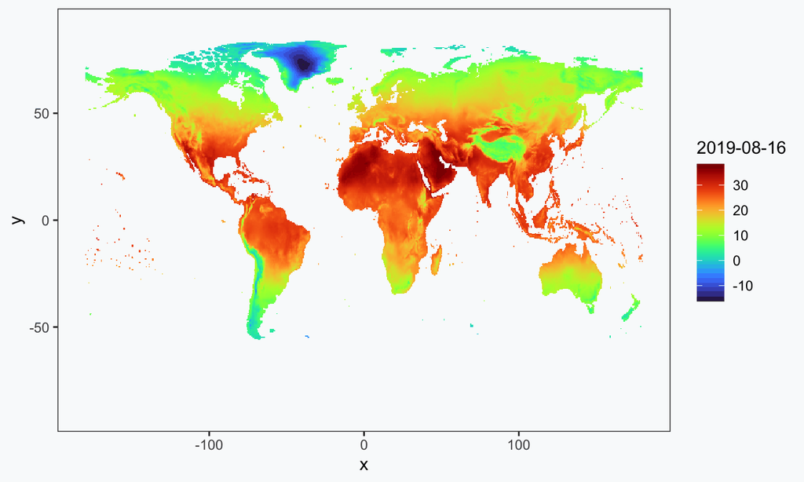

## Temperature

You can download temperature data from by going to https://archive.ceda.ac.uk

## Temperature

You can download temperature data from by going to https://archive.ceda.ac.uk

## Temperature

You can download temperature data from by going to https://archive.ceda.ac.uk

## Temperature

You can download temperature data from by going to https://archive.ceda.ac.uk

## Temperature

You can download temperature data from by going to https://archive.ceda.ac.uk

## Temperature

You can download temperature data from by going to https://archive.ceda.ac.uk

## Temperature

You can download temperature data from by going to https://archive.ceda.ac.uk

## Temperature

You can download temperature data from by going to https://archive.ceda.ac.uk

## Temperature

You can download temperature data from by going to https://archive.ceda.ac.uk

## Temperature

You can download temperature data from by going to https://archive.ceda.ac.uk

## Temperature

You can download temperature data from by going to https://archive.ceda.ac.uk

## Temperature

You can download temperature data from by going to https://archive.ceda.ac.uk

## Temperature

You can download temperature data from by going to https://archive.ceda.ac.uk

## Temperature

You can download temperature data from by going to https://archive.ceda.ac.uk

## Temperature

You can download temperature data from by going to https://archive.ceda.ac.uk

## Temperature

You can download temperature data from by going to https://archive.ceda.ac.uk

## Temperature

You can download temperature data from by going to https://archive.ceda.ac.uk

## Temperature

You can download temperature data from by going to https://archive.ceda.ac.uk

## Temperature

You can download temperature data from by going to https://archive.ceda.ac.uk

## Temperature

You can download temperature data from by going to https://archive.ceda.ac.uk

## Temperature

You can download temperature data from by going to https://archive.ceda.ac.uk

## Temperature

You can [download the CRU file](https://www.dropbox.com/scl/fi/adx4qxls6b7b6wo2g0bbe/cru_ts4.07.1901.2022.tmp.dat.nc?rlkey=4qzd8grkubs7trbo0izhgyx1m&dl=0) (3.04 GB)

Place it in a folder called “temp”

## Reading Temperature

Here is how we can read the file

```r
library(terra)
library(sf)
library(stars)
library(ggplot2)
#Step1: Read the raster
b <- terra::rast("./datal17/temp/cru_ts4.07.1901.2022.tmp.dat.nc")
```

This is the type of file we deal with

```r
class(b)
```

```
[1] "SpatRaster"
attr(,"package")
[1] "terra"
```

## Reading Temperature

We then we extract the time component

```r
#Step2: Extract time information
time_values <- time(b)
```

Let’s print the first 10 entries

```r
time_values[1:10]
```

```
 [1] "1901-01-16" "1901-02-15" "1901-03-16" "1901-04-16" "1901-05-16"
 [6] "1901-06-16" "1901-07-16" "1901-08-16" "1901-09-16" "1901-10-16"
```

```r
min(time_values)
```

```
[1] "1901-01-16"
```

```r
max(time_values)
```

```
[1] "2022-12-16"
```

## Reading Temperature

We now turn those numbers into Date objects

```r
#Step3: Turning strings into time
date_objects <- as.Date(time_values)
```

```r
date_objects[1:10]
```

```
 [1] "1901-01-16" "1901-02-15" "1901-03-16" "1901-04-16" "1901-05-16"
 [6] "1901-06-16" "1901-07-16" "1901-08-16" "1901-09-16" "1901-10-16"
```

```r
min(date_objects)
```

```
[1] "1901-01-16"
```

```r
max(date_objects)
```

```
[1] "2022-12-16"
```

## Reading Temperature

We can select all the dates from 1901 and 2022

```r
#Step4: Select only the dates from the year 1901 and 2022
dates_1901 <- date_objects[format(date_objects, "%Y") == "1901"]
dates_2022 <- date_objects[format(date_objects, "%Y") == "2022"]
```

```r
print(dates_1901)
```

```
 [1] "1901-01-16" "1901-02-15" "1901-03-16" "1901-04-16" "1901-05-16"
 [6] "1901-06-16" "1901-07-16" "1901-08-16" "1901-09-16" "1901-10-16"
[11] "1901-11-16" "1901-12-16" "1901-01-16" "1901-02-15" "1901-03-16"
[16] "1901-04-16" "1901-05-16" "1901-06-16" "1901-07-16" "1901-08-16"
[21] "1901-09-16" "1901-10-16" "1901-11-16" "1901-12-16"
```

```r
print(dates_2022)
```

```
 [1] "2022-01-16" "2022-02-15" "2022-03-16" "2022-04-16" "2022-05-16"
 [6] "2022-06-16" "2022-07-16" "2022-08-16" "2022-09-16" "2022-10-16"
[11] "2022-11-16" "2022-12-16" "2022-01-16" "2022-02-15" "2022-03-16"
[16] "2022-04-16" "2022-05-16" "2022-06-16" "2022-07-16" "2022-08-16"
[21] "2022-09-16" "2022-10-16" "2022-11-16" "2022-12-16"
```

## Reading Temperature

We next need to identify the index of those dates

```r
#Step5: Find the index of the selected dates in the time_values
selected_indices_1901 <- which(time_values %in% as.Date(dates_1901))
selected_indices_2022 <- which(time_values %in% as.Date(dates_2022))
```

```r
print(selected_indices_1901)
```

```
 [1]    1    2    3    4    5    6    7    8    9   10   11   12 1465 1466 1467
[16] 1468 1469 1470 1471 1472 1473 1474 1475 1476
```

```r
print(selected_indices_2022)
```

```
 [1] 1453 1454 1455 1456 1457 1458 1459 1460 1461 1462 1463 1464 2917 2918 2919
[16] 2920 2921 2922 2923 2924 2925 2926 2927 2928
```

## Reading Temperature

We can now extract those rasters from the spatraster `b` using those indices

```r
#Step6: Extract raster values for the selected dates
selected_rasters_1901 <- b[[selected_indices_1901]]
selected_rasters_2022 <- b[[selected_indices_2022]]
```

Here is for example what the 1901 spatraster looks like:

```r
class(selected_rasters_1901)
```

```
[1] "SpatRaster"
attr(,"package")
[1] "terra"
```

```r
print(selected_rasters_1901)
```

```
class       : SpatRaster
size        : 360, 720, 24  (nrow, ncol, nlyr)
resolution  : 0.5, 0.5  (x, y)
extent      : -180, 180, -90, 90  (xmin, xmax, ymin, ymax)
coord. ref. : lon/lat WGS 84 (CRS84) (OGC:CRS84)
sources     : cru_ts4.07.1901.2022.tmp.dat.nc
varnames    : stn
              tmp (near-surface temperature)
names       : stn_1, stn_2, stn_3, stn_4, stn_5, stn_6, ...
unit        :      ,      ,      ,      ,      ,      , ...
time (days) : 1901-01-16 to 1901-12-16 (12 steps)
```

## Reading Temperature

We can then save the names of the rasters:

```r
#Step7: Extract layer names
layer_names_1901 <- names(selected_rasters_1901)
layer_names_2022 <- names(selected_rasters_2022)
```

Here is what they look like:

```r
print(layer_names_1901)
```

```
 [1] "stn_1"  "stn_2"  "stn_3"  "stn_4"  "stn_5"  "stn_6"  "stn_7"  "stn_8"
 [9] "stn_9"  "stn_10" "stn_11" "stn_12" "tmp_1"  "tmp_2"  "tmp_3"  "tmp_4"
[17] "tmp_5"  "tmp_6"  "tmp_7"  "tmp_8"  "tmp_9"  "tmp_10" "tmp_11" "tmp_12"
```

## Temperature

This is what we have covered so far:

```r
library(terra)
library(sf)
library(stars)
#Step1: Read the raster
b <- rast("./datal17/temp/cru_ts4.07.1901.2022.tmp.dat.nc")

#Step2: Extract time information
time_values <- time(b)

#Step3: Turning strings into time
date_objects <- as.Date(time_values)

#Step4: Select only the dates from the year 1901 and 2022
dates_1901 <- unique(date_objects[format(date_objects, "%Y") == "1901"])
dates_2022 <- unique(date_objects[format(date_objects, "%Y") == "2022"])

#Step5: Find the index of the selected dates in the time_values
selected_indices_1901 <- which(time_values %in% as.Date(dates_1901))
selected_indices_2022 <- which(time_values %in% as.Date(dates_2022))

#Step6: Extract raster values for the selected dates
selected_rasters_1901 <- b[[selected_indices_1901]]
selected_rasters_2022 <- b[[selected_indices_2022]]

#Step7: Extract layer names
layer_names_1901 <- names(selected_rasters_1901)
layer_names_2022 <- names(selected_rasters_2022)
```

## Temperature

We then extract the the index of the layers that start with `tmp`

We need to do this because there are other types of laters inside this `.nc` file: `stn` - number of stations contributing to each interpolation

```r
#Step8: Find indices of layers that start with "tmp"
#tmp stands for temperature. There are other rasters within these files.
indices_tmp_1901 <- grep("^tmp", layer_names_1901)
```

This is what `indices_tmp_1901` looks like

```r
print(indices_tmp_1901)
```

```
 [1] 13 14 15 16 17 18 19 20 21 22 23 24
```

## Temperature

We then select only the temperature rasters

```r
tmp_layers_1901 <- selected_rasters_1901[[indices_tmp_1901]]
```

Here is what `tmp_layers_1901` looks like:

```r
print(tmp_layers_1901)
```

```
class       : SpatRaster
size        : 360, 720, 12  (nrow, ncol, nlyr)
dimensions  : lon, lat, time (720, 360, 1464}
resolution  : 0.5, 0.5  (x, y)
extent      : -180, 180, -90, 90  (xmin, xmax, ymin, ymax)
coord. ref. : lon/lat WGS 84 (CRS84) (OGC:CRS84)
source      : cru_ts4.07.1901.2022.tmp.dat.nc
varname     : tmp (near-surface temperature)
names       : tmp_1, tmp_2, tmp_3, tmp_4, tmp_5, tmp_6, ...
unit        : degrees Celsius
time (days) : 1901-01-16 to 1901-12-16 (12 steps)
```

## Temperature

We then do the same for 2022

```r
#Step8: Find indices of layers that start with "tmp"
#tmp stands for temperature. There are other rasters within these files.
indices_tmp_2022 <- grep("^tmp", layer_names_2022)
tmp_layers_2022 <- selected_rasters_2022[[indices_tmp_2022]]
```

Here is what `tmp_layers_2022` looks like

```r
print(tmp_layers_2022)
```

```
class       : SpatRaster
size        : 360, 720, 12  (nrow, ncol, nlyr)
dimensions  : lon, lat, time (720, 360, 1464}
resolution  : 0.5, 0.5  (x, y)
extent      : -180, 180, -90, 90  (xmin, xmax, ymin, ymax)
coord. ref. : lon/lat WGS 84 (CRS84) (OGC:CRS84)
source      : cru_ts4.07.1901.2022.tmp.dat.nc
varname     : tmp (near-surface temperature)
names       : tmp_1453, tmp_1454, tmp_1455, tmp_1456, tmp_1457, tmp_1458, ...
unit        : degrees Celsius
time (days) : 2022-01-16 to 2022-12-16 (12 steps)
```

## Temperature

We can then rename the layers

```r
names(tmp_layers_1901)
```

```
 [1] "tmp_1"  "tmp_2"  "tmp_3"  "tmp_4"  "tmp_5"  "tmp_6"  "tmp_7"  "tmp_8"
 [9] "tmp_9"  "tmp_10" "tmp_11" "tmp_12"
```

We should rename those using:

```r
dates_1901
```

```
 [1] "1901-01-16" "1901-02-15" "1901-03-16" "1901-04-16" "1901-05-16"
 [6] "1901-06-16" "1901-07-16" "1901-08-16" "1901-09-16" "1901-10-16"
[11] "1901-11-16" "1901-12-16"
```

Finally, this is how we rename them:

```r
#Step9: Changing raster names to temperature
names(tmp_layers_1901)<-dates_1901
names(tmp_layers_2022)<-dates_2022
```

Let us look again at the output:

```r
names(tmp_layers_1901)
```

```
 [1] "1901-01-16" "1901-02-15" "1901-03-16" "1901-04-16" "1901-05-16"
 [6] "1901-06-16" "1901-07-16" "1901-08-16" "1901-09-16" "1901-10-16"
[11] "1901-11-16" "1901-12-16"
```

## Temperature

We then need to turn our spatraster object into a raster object

```r
#Step10: Turning the spatraster into a list of raster
stars_list_1901 <- lapply(tmp_layers_1901, function(raster_obj) st_as_stars(raster::raster(raster_obj)))
stars_list_2022 <- lapply(tmp_layers_2022, function(raster_obj) st_as_stars(raster::raster(raster_obj)))
```

Notice the difference

```r
class(tmp_layers_1901)
```

```
[1] "SpatRaster"
attr(,"package")
[1] "terra"
```

```r
class(stars_list_1901)
```

```
[1] "list"
```

## Temperature `lapply()`

`lapply()` is a fundamental function in R used to apply a given function to each element of a list or vector.

The name “lapply” stands for “list apply,” highlighting its primary usage with lists.

Syntax:  
lapply(X, FUN, …)

```r
# Create a list
my_df <- data.frame(a = 1:3, b = 4:6)

# Define a function to square each element
square <- function(x) {
  return(x^2)
}

# Apply the square function to each element of the list
result <- lapply(my_df, square)
```

## Temperature `lapply()`

This what that final dataframe looks like:

```r
# Create a list
# Convert the list result to a dataframe
result <- as.data.frame(result)

# Output the result
print(result)
```

```
  a  b
1 1 16
2 4 25
3 9 36
```

## Temperature: One-line functions

In R, it’s common to use anonymous or in-line functions for concise code

These functions are defined on-the-fly and typically used when the function is simple and doesn’t require reusability.

Thus, we can write:

```r
# Example of creating stars objects from raster layers using lapply and an inline function
stars_list_1901 <- lapply(tmp_layers_1901, function(raster_obj) st_as_stars(raster::raster(raster_obj)))
```

or

```r
# Define the function separately
convert_to_stars <- function(raster_obj) {
  return(st_as_stars(raster::raster(raster_obj)))
}

# Apply the function using lapply
stars_list_1901 <- lapply(tmp_layers_1901, convert_to_stars)
```

## Temperature

```r
#Step11: Use lapply to apply st_apply to each stars object to calculate the mean
mean_list_1901 <- lapply(stars_list_1901, function(stars_obj) st_apply(stars_obj, c("x", "y"), mean))
mean_list_2022 <- lapply(stars_list_2022, function(stars_obj) st_apply(stars_obj, c("x", "y"), mean))
```

Notice that the input is `stars_list_1901`

`stars_list_1901` is a list of stars object containing 12 objects

## Temperature

You can see below the first object in the `stars_list_1901`

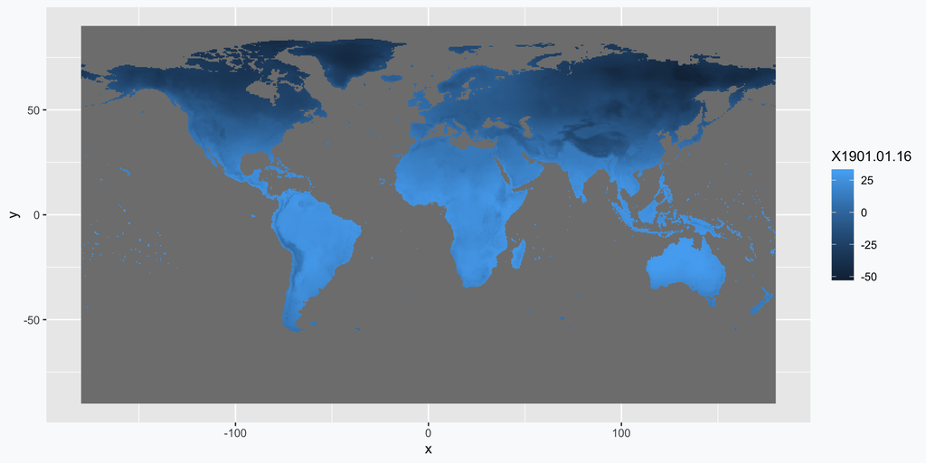

```r
ggplot()+
  geom_stars(data=stars_list_1901[[1]])
```

## Temperature

You can see below the second object in the `stars_list_1901`

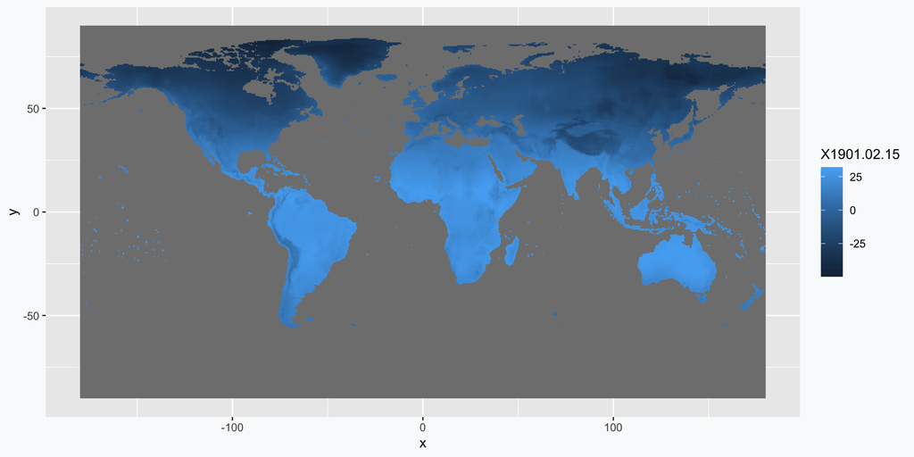

```r
ggplot()+
  geom_stars(data=stars_list_1901[[2]])
```

## Temperature

```r
#Step11: Use lapply to apply st_apply to each stars object to calculate the mean
mean_list_1901 <- lapply(stars_list_1901, function(stars_obj) st_apply(stars_obj, c("x", "y"), mean))
mean_list_2022 <- lapply(stars_list_2022, function(stars_obj) st_apply(stars_obj, c("x", "y"), mean))
```

Here is what one item looks like:

```r
class(mean_list_1901[[1]])
```

```
[1] "stars"
```

```r
class(stars_list_1901[[1]])
```

```
[1] "stars"
```

Here is what the object looks like

```r
class(mean_list_1901)
```

```
[1] "list"
```

## Temperature

We then combine the list of results into a single stars object

```r
#Step12: Combine the list of results into a single stars object
mean_stars_1901 <- do.call(stars::st_as_stars, mean_list_1901)
mean_stars_2022 <- do.call(stars::st_as_stars, mean_list_2022)
```

do.call() Function calls a function with a list of arguments

```r
# Example usage of do.call
my_list <- list(a = 1, b = 2)
do.call(sum, my_list)
```

```
[1] 3
```

## Temperature

We then combine the list of results into a single stars object

```r
#Step12: Combine the list of results into a single stars object
mean_stars_1901 <- do.call(stars::st_as_stars, mean_list_1901)
mean_stars_2022 <- do.call(stars::st_as_stars, mean_list_2022)
```

## Temperature

This is the result:

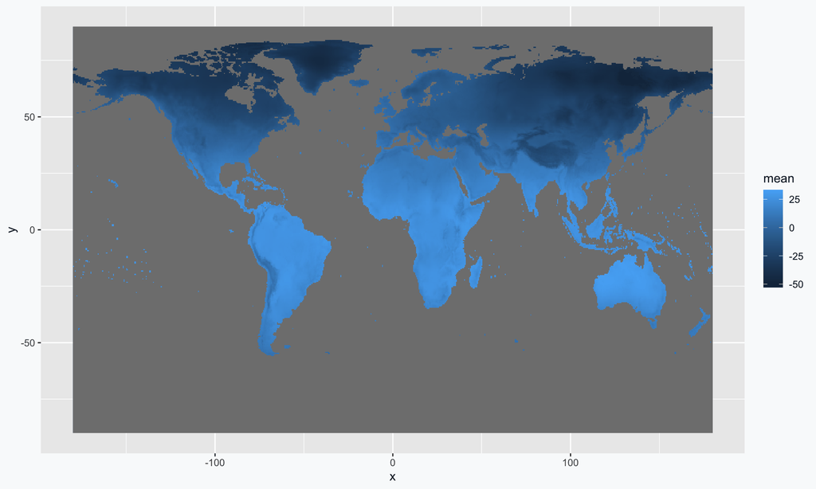

```r
ggplot()+
  geom_stars(data=mean_stars_1901)
```

## Temperature

These are the steps that we covered in part 2.

```r
#Step8: Find indices of layers that start with "tmp"
#tmp stands for temperature. There are other rasters within these files.
indices_tmp_1901 <- grep("^tmp", layer_names_1901)
tmp_layers_1901 <- selected_rasters_1901[[indices_tmp_1901]]
indices_tmp_2022 <- grep("^tmp", layer_names_2022)
tmp_layers_2022 <- selected_rasters_2022[[indices_tmp_2022]]

#Step9: Changing raster names to temperature
names(tmp_layers_1901)<-dates_1901
names(tmp_layers_2022)<-dates_2022

#Step10: Turning the spatraster into raster
stars_list_1901 <- lapply(tmp_layers_1901, function(obj) st_as_stars(raster::raster(obj)))
stars_list_2022 <- lapply(tmp_layers_2022, function(obj) st_as_stars(raster::raster(obj)))

#Step11: Use lapply to apply st_apply to each stars object to calculate the mean
mean_list_1901 <- lapply(stars_list_1901, function(stars_obj) st_apply(stars_obj, c("x", "y"), mean))
mean_list_2022 <- lapply(stars_list_2022, function(stars_obj) st_apply(stars_obj, c("x", "y"), mean))

#Step12: Combine the list of results into a single stars object
mean_stars_1901 <- do.call(stars::st_as_stars, mean_list_1901)
mean_stars_2022 <- do.call(stars::st_as_stars, mean_list_2022)

#Step13: Changing the name of the rasters
names(mean_stars_1901)<-"avg_tmp_1901"
names(mean_stars_2022)<-"avg_tmp_2022"
```

## Temperature

Temperature in 1901

```r
library(viridis)
fig<-ggplot()+
  geom_stars(data=mean_stars_1901)+
  scale_fill_viridis(option="turbo", na.value=NA)+
  theme_bw()+
  theme(panel.grid.major = element_blank(), panel.grid.minor = element_blank())
```

## Temperature

Temperature in 1901

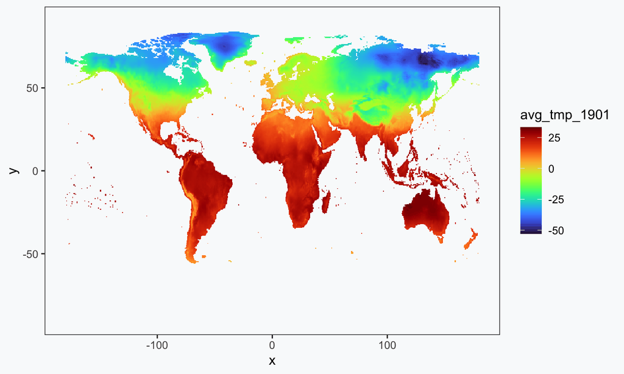

## Temperature

Temperature in 2022

```r
fig<-ggplot()+
  geom_stars(data=mean_stars_2022)+
  scale_fill_viridis(option="turbo", na.value=NA)+
  theme_bw()+
  theme(panel.grid.major = element_blank(), panel.grid.minor = element_blank())
```

## Temperature

Temperature in 2022

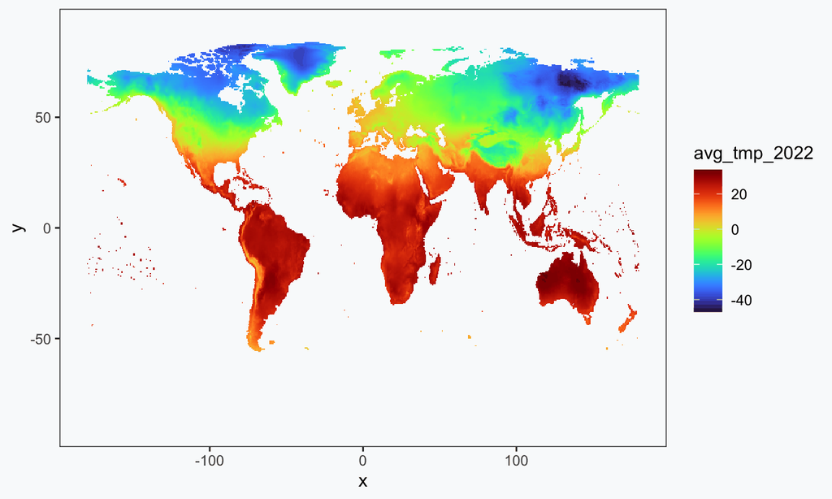

## Working with Temperature

Now plotting was to some extent straightforward.

What if we wanted to extract the average temperature for every single year and make a time plot?

## Working with Temperature

This is where our programming skills come in handy from earlier lectures

```r
library(terra)

# Step 1: Read the raster
b <- rast("./datal17/temp/cru_ts4.07.1901.2022.tmp.dat.nc")

# Step 2: Extract time information
time_values <- time(b)

# Step 3: Turning strings into time
date_objects <- as.Date(time_values)

# Step 4: Get unique years
unique_years <- unique(format(date_objects, "%Y"))
#All years take too long, so we will only choose two years
unique_years <-c("2021", "2022")

# Step 5: Create an empty list to store mean stars for each year
mean_stars_list <- list()
```

## Working with Temperature

This is where our programming skills come in handy from earlier lectures

```r
# Step 6: Iterate over each unique year
for (year in unique_years) {
  cat("Calculating average for year", year, "\n")
  #Step1: Select dates for the current year
  selected_dates <- unique(date_objects[format(date_objects, "%Y") == year])
  #Step2: Find the index of the selected dates in the time_values
  selected_indices <- which(time_values %in% as.Date(selected_dates))
  #Step3: Extract raster values for the selected dates
  selected_rasters <- b[[selected_indices]]
  #Step4: Extract layer names
  layer_names <- names(selected_rasters)
  #Step5: Find indices of layers that start with "tmp"
  indices_tmp <- grep("^tmp", layer_names)
  #Step6: Extract temperature layers
  tmp_layers <- selected_rasters[[indices_tmp]]
  #Step7: Change raster names to temperature
  names(tmp_layers) <- selected_dates
  #Step8: Convert spatraster into raster
  stars_list <- lapply(tmp_layers, function(raster_obj) st_as_stars(raster::raster(raster_obj)))
  #Step9: Use lapply to apply st_apply to each stars object to calculate the mean
  mean_list <- lapply(stars_list, function(stars_obj) st_apply(stars_obj, c("x", "y"), mean))
  #Step10: Combine the list of results into a single stars object
  mean_stars <- do.call(stars::st_as_stars, mean_list)
  #Step11: Change the name of the raster
  names(mean_stars) <- paste("avg_tmp", year, sep = "_")
  #Step12: Add the mean stars to the list
  mean_stars_list[[year]] <- mean_stars
  cat("Average calculation for year", year, "completed\n\n")
}
```

```
Calculating average for year 2021
```

```
Average calculation for year 2021 completed

Calculating average for year 2022
```

```
Average calculation for year 2022 completed
```

## Working with Temperature

This is where our programming skills come in handy from earlier lectures

```r
# Combine all the mean stars into a single stars object
# Initialize an empty data frame
result_df <- data.frame()

# Loop through each year and calculate the mean
for (year in names(mean_stars_list)) {
  #Creating an object where we look through the years
  avg_tmp_col_name <- paste0("avg_tmp_", year)
  #Calculating mean and keeping track of the year
  mean_value <- mean(mean_stars_list[[year]][[avg_tmp_col_name]], na.rm = TRUE)
  #Saving everything into a dataframe
  result_df <- rbind(result_df, data.frame(year = as.numeric(year), average_temperature = mean_value))
}

# Writing the df to a dataframe
write.csv(result_df, "./datal17/output/average_temp_2021_2022.csv", row.names = FALSE)
```

## Working with Temperature

So, we wrote our dataframe to a csv file.

Note that we did this dataframe for two years only: 2021 and 2022.

To complete the loop for all years, put a `#` in front of  
`unique_years <-c("2021", "2022")`

This means that `unique_years` is an object made out of  
`unique(format(date_objects, "%Y"))`

To save you time, I have already done all the years on my machine. You can download the [csv file with all the years](https://www.dropbox.com/scl/fi/kk8xb8k350gj5u4mp2cdn/average_temp_1901_2022.csv?rlkey=qj99nwrwjbqf27n976d35hsll&dl=0).

Put it in the relevant folder

## Working with Temperature

```r
#write.csv(result_df, "./datal17/output/average_temp_1901_2022.csv", row.names = FALSE)
#Reading the file
average_temp<-read.csv("./datal17/output/average_temp_1901_2022.csv")
#Subsetting to below 2001
average_temp_1901_2000<-subset(average_temp, year<2001)
#Calculating the 1901-2000 average
average_temp_1901_2000<-mean(average_temp_1901_2000$average_temperature)
#Calculation the deviations from the 1901-2000 average
average_temp$dev_1901_2000_avg<-average_temp$average_temperature-average_temp_1901_2000
```

## Working with Temperature

Creating a time trend

```r
#Mapping the Temperature Deviaitonsover time
ggplot(average_temp, aes(x = year, y = dev_1901_2000_avg)) +
  geom_line() +
  geom_point() +
  theme_bw()+
  labs(title = "Time Trend of Average Temperature",
       x = "Year",
       y = "Average Temperature")
```

## Working with Temperature

Creating a time trend

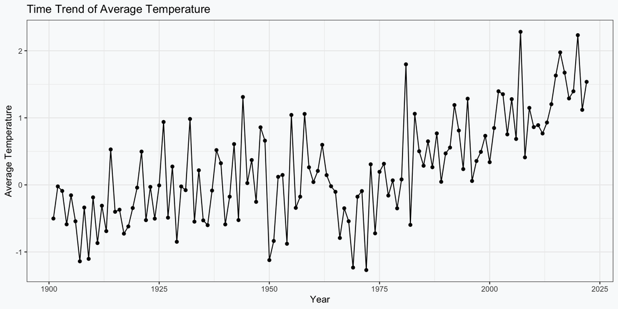

## Working with Temperature

Creating a bar plot with the values

```r
# Create a new column for bar color based on the condition
average_temp$bar_color <- ifelse(average_temp$dev_1901_2000_avg > 0, "red", "blue")

# Create the bar plot
ggplot(average_temp, aes(x = year, y = dev_1901_2000_avg, fill = bar_color)) +
  geom_bar(stat = "identity", color = "black") +
  scale_fill_manual(values = c("blue", "red"), guide="none") +
  theme_bw() +
  labs(title = "Time Trend of Average Temperature",
       x = "Year",
       y = "Difference from 1901-2000 avearge (degrees C)")
```

## Working with Temperature

Creating a bar plot with the values

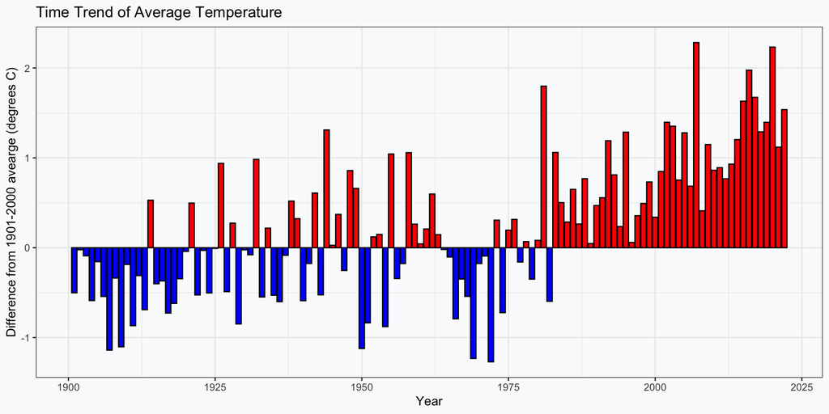

## Working with Temperature

This is very close to the official figures produced by NOAA (National Ceneter for Environmental Information)

See: https://www.ncei.noaa.gov/access/monitoring/climate-at-a-glance/global/time-series/globe/land/1/11/1901-2022.

## What Have We Learned?

We have covered a lot of operations related to rasters

We learned about:

- nc temperature rasters
- different types of raster formats: spatraster, raster, and stars
- accessing raster values
- doing raster algebra: calculating average cell temperature
- examining temperature over time